# Week3 tutorial keynote

Author

Patrick Li

If you can not answer the question given in this keynote or do not fully understand the concepts, **I highly recommend you to post your questions on forum or go to a consultation.**

The stock simulation game can be downloaded from [here](https://github.com/TengMCing/stock_sim/blob/master/stock_simulation.R). Note that you need to install `bandicoot` via the command `remotes::install_github("TengMCing/bandicoot")` before running the game.

## Exercise 3A

### 1. familiarise yourself with the following functions and the corresponding concepts:

```r
?shiny::fluidPage
?shiny::actionButton
?shiny::htmlOutput
```

- Read [this article](https://shiny.rstudio.com/articles/layout-guide.html) for better understanding of the shiny layout system.
- Read the shiny official tutorial [lesson 3](https://shiny.rstudio.com/tutorial/written-tutorial/lesson3/) to understand input widgets.
- Read [lesson 4](https://shiny.rstudio.com/tutorial/written-tutorial/lesson4/) to understand reactive output.

Although you have encountered these concepts in the lecture, it is encouraged to read the above materials to gain insights of shiny. Don’t be afraid to read documentation via `?<function_name>` when you need to. In most of the time, package reference is what you can truly rely on.

Ask yourself the following questions once you finished reading the materials:

1. What is the fluid grid system?
2. Open an app with a clean layout on your mobile phone, can you use the fluid grid system to describe how such a layout can be structured?

### 2. `id` of a widget

The first parameter of some shiny UI functions is `inputId` or `outputId`. If you inspect the html code in your browser, you will find the HTML attribute `id` is the same as the `inputId` or `outputId` you specify in your R code. This indicates you can select these widgets with `#<inputId> {}` or `#<outputId> {}` in CSS.

### 3. `sample()`

Read the documentation of the `?sample()` function. It is one of the most important statistical functions in R.

Try to run the following expressions and consider these questions:

- What do parameter `size` and `replace` mean?
- What are the differences between expressions?
- Why does a line of code throw an error?

```r
sample(10)
sample(1:10)
sample(1:10, size = 1)
sample(1:10, replace = TRUE)
sample(c("H", "T"), size = 10)
sample(c("H", "T"), size = 10, replace = TRUE)
```

### 4. reactive programming

The basic of reactive expression can be learned from [lesson 6](https://shiny.rstudio.com/tutorial/written-tutorial/lesson6/). The logic of the reactive programming has been explained in detail from [chapter 13 to chapter 16 in Mastering Shiny](https://mastering-shiny.org/reactivity-intro.html).

After the read, try to answer the following questions:

1. What is a reactive expression?
2. What is an observer or output?
3. How to declare dependencies between components?
4. How does the shiny reactive system construct the dependency graph during the application start-up?
5. Will a reactive expression be evaluated during the start-up if no other components depends on it?
6. Will an observer or output be evaluated during the start-up?
7. What is invalidation?
8. When does invalidation kick off?
9. When will a reactive expression be re-evaluated? Does reactive expression re-evaluated once it is invalidated?
10. When will an observer and output be re-evaluated? Does an observer and output re-evaluated once it is invalidated?
11. What is `isolate()`? Why do we need it?

In [chapter 14 of Mastering Shiny](https://mastering-shiny.org/reactive-graph.html), the author introduces a useful package called `reactlog` for debugging shiny application. Learn how to turn on the **reactlog** and interact with it.

What will be printed on the console (1) when the application is launched, and (2) when the button is clicked? If you can not accurately predict the behaviour, try to follow the `reactlog` to understand it.

```r
ui <- fluidPage(
   actionButton("flip", "Test flip"),
   textOutput("estimate")
)

server <- function(input, output, session) {

  reactive_out <- reactive({
    print("reactive_out")
    input$flip
  })

  reactive_out2 <- reactive({
    print("reactive_out2")
    isolate(input$flip)
  })

  observe_out <- observe({
    print("observe_out")
    input$flip
  })

  observe_out2 <- observe({
    print("observe_out2")
    isolate(input$flip)
  })

  output$estimate <- renderText({
    if (input$flip) {
      print("ouput$estimate")
      reactive_out2()
    }
  })
}

shinyApp(ui, server)
```

### 5. `htmltools`

`htmltools` is a package for generating HTML code. You have learned how to include tags like `h1()` in your shiny app during the lecture.

However, to be able to dynamically manage the HTML code we need some advanced functions. Section [Modify tag content](https://rstudio.github.io/htmltools/reference/tagAppendChild.html) of the reference of `htmltools` introduces four functions to modify html tags.

If you check the data structure of a html tag, you will find that it is a list with all the inner tags storing in the field `children`.

```r
library(htmltools)
x <- div(h1(), h2())
print(x)
```

```
<div>
  <h1></h1>
  <h2></h2>
</div>
```

```r
str(x)
```

```
List of 3
 $ name    : chr "div"
 $ attribs : Named list()
 $ children:List of 2
  ..$ :List of 3
  .. ..$ name    : chr "h1"
  .. ..$ attribs : Named list()
  .. ..$ children: list()
  .. ..- attr(*, "class")= chr "shiny.tag"
  ..$ :List of 3
  .. ..$ name    : chr "h2"
  .. ..$ attribs : Named list()
  .. ..$ children: list()
  .. ..- attr(*, "class")= chr "shiny.tag"
 - attr(*, "class")= chr "shiny.tag"
```

`tagAppendChildren` will append tags to the `children` field.

```r
str(tagAppendChildren(x, p()))
```

```
List of 3
 $ name    : chr "div"
 $ attribs : Named list()
 $ children:List of 3
  ..$ :List of 3
  .. ..$ name    : chr "h1"
  .. ..$ attribs : Named list()
  .. ..$ children: list()
  .. ..- attr(*, "class")= chr "shiny.tag"
  ..$ :List of 3
  .. ..$ name    : chr "h2"
  .. ..$ attribs : Named list()
  .. ..$ children: list()
  .. ..- attr(*, "class")= chr "shiny.tag"
  ..$ :List of 3
  .. ..$ name    : chr "p"
  .. ..$ attribs : Named list()
  .. ..$ children: list()
  .. ..- attr(*, "class")= chr "shiny.tag"
 - attr(*, "class")= chr "shiny.tag"
```

`tagSetChildren` will override tags in the `children` field.

```r
str(tagSetChildren(x, p()))
```

```
List of 3
 $ name    : chr "div"
 $ attribs : Named list()
 $ children:List of 1
  ..$ :List of 3
  .. ..$ name    : chr "p"
  .. ..$ attribs : Named list()
  .. ..$ children: list()
  .. ..- attr(*, "class")= chr "shiny.tag"
 - attr(*, "class")= chr "shiny.tag"
```

If you would like to delete a inner tag, you can simply set that tag to be `NULL`.

```r
x$children[[1]] <- NULL
str(x)
```

```
List of 3
 $ name    : chr "div"
 $ attribs : Named list()
 $ children:List of 1
  ..$ :List of 3
  .. ..$ name    : chr "h2"
  .. ..$ attribs : Named list()
  .. ..$ children: list()
  .. ..- attr(*, "class")= chr "shiny.tag"
 - attr(*, "class")= chr "shiny.tag"
```

### 6. Global variable and local variable

Knowing how `R` performs variable lookup is very important since every reactive expression and observer is a function. The following code chunk demonstrates this mechanism.

```r
# Define a global variable x
x <- 1

foo <- function() {
  # `print()` tries to find `x` inside this function but it does not exist
  # `print()` then tries to find `x` from its parent environment,
  # which in this case, the global environment
  print(paste("Print from foo:", x))
}

foo2 <- function() {
  # Define a local variable x.
  x <- 2

  # `print()` tries to find `x` inside this function and it does exist
  print(paste("Print from foo2:", x))
}

foo3 <- function() {
  # `print()` tries to find `x` inside this function but it does not exist
  # `print()` then tries to find `x` from its parent environment,
  # which in this case, the global environment
  print(paste("Print from foo3 first time:", x))

  # Define a local variable x
  x <- 3

  # Call foo()
  foo()

  # Call foo2()
  foo2()

  # `print()` tries to find `x` inside this function and it does exist
  print(paste("Print from foo3 second time:", x))
}
```

```r
foo()
```

```
[1] "Print from foo: 1"
```

```r
foo2()
```

```
[1] "Print from foo2: 2"
```

```r
foo3()
```

```
[1] "Print from foo3 first time: 1"
[1] "Print from foo: 1"
[1] "Print from foo2: 2"
[1] "Print from foo3 second time: 3"
```

```r
# `print()` tries to find `x` in the global environment and it does exist
print(paste("Print from global environment:", x))
```

```
[1] "Print from global environment: 1"
```

### 7. `<-` and `<<-`

Note that calling `<-` inside a function will only assign the value to a local variable. To be able to assign values to parent environments, such as the global environment, the `<<-` operator need to be used.

```r
# Define a global variable x
x <- 1

# Define an immediately invoked function and run it
(function() x <- 2)()
x
```

```
[1] 1
```

```r
# Define a global variable x
x <- 1

# Define an immediately invoked function and run it
(function() x <<- 2)()
x
```

```
[1] 2
```

This is equivalent to call `assign()` with the appropriate environment.

```r
# Define a global variable x
x <- 1

# Define an immediately invoked function and run it
(function() assign("x", 2, envir = .GlobalEnv))()
x
```

```
[1] 2
```

### 8. `paste()` and `paste0()`

```r
# Both `paste` and `paste0` will try to convert the inputs to strings
paste("a", 1L, 2.3)
```

```
[1] "a 1 2.3"
```

```r
paste0("a", 1L, 2.3)
```

```
[1] "a12.3"
```

There are two useful parameters in `paste()`, namely `sep` and `collapse`. `sep` allows you to insert strings between tokens, while `collapse` allows you to concatenate the result if it is a vector of strings.

```r
# The result is a vector of strings
paste(c(12, 23, 34))
```

```
[1] "12" "23" "34"
```

```r
# Concatenate the result with nothing in between
paste(c(12, 23, 34), collapse = "")
```

```
[1] "122334"
```

```r
# Concatenate the result with a white space in between
paste(c(12, 23, 34), collapse = " ")
```

```
[1] "12 23 34"
```

```r
# The result is a vector of strings
paste(c(12, 23, 34), c("a", "b", "c"))
```

```
[1] "12 a" "23 b" "34 c"
```

```r
# Insert ":" between tokens, the result is still a vector of strings
paste(c(12, 23, 34), c("a", "b", "c"), sep = ":")
```

```
[1] "12:a" "23:b" "34:c"
```

```r
# Concatenate the result with a comma and a white space in between
paste(c(12, 23, 34), c("a", "b", "c"), sep = ":", collapse = ", ")
```

```
[1] "12:a, 23:b, 34:c"
```

## Exercise 3B

### 9. Debugging your shiny app

There are many ways to debug code. The fundamental approach works in most of the programming language will be `print()` or the equivalent function and macro defined in the language. You can insert `print()` into the places you think which contains bugs.

In `R`, the preferable way will be to invoke a call to `browser()` which will halt the evaluation of an expression and allow for inspection. But usually, the `R` error and warning message is meaningful enough to spot the bug.

### 10. Updating inputs

Read the [10.1 Updating inputs and 10.1.1 Simple uses](https://mastering-shiny.org/action-dynamic.html?q=update#updating-inputs) to know the basic of updating inputs. It is a very powerful tool that can be used to control the UI at run-time. You don’t have to provide `session` as the first argument but it is recommended to provide one.

## Exercise 3C

The content of this section are adopted from Casella and Berger (2002). You don’t need to read the book as it is not beginner friendly, but I will use the definitions and examples here for demonstration.

### 11. Random sample, statistic and sampling distribution

As defined in page 207 of Casella and Berger (2002):

**Definition 5.1.1** The random variables $X_1,...,X_n$ are called a *random sample of size $n$ from the population* $f(x)$ if $X_1,...,X_n$ are mutually independent random variables and the marginal pdf or pmf of each $X_i$ is the same function $f(x)$. Alternatively, $X_1, ..., X_n$ are called *independent and identically distributed random variables with pdf or pmf* $f(x)$. This is commonly abbreviated to iid random variables.

And in page 211:

**Definition 5.2.1** Let $X_1, ..., X_n$ be a random sample of size $n$ from a population and let $T(x_1,...,x_n)$ be a real-valued or vector-valued function whose domain includes the sample space of $(X_1,...,X_n)$. Then the random variable or random vector $Y = T(X_1,...,X_n)$ is called a *statistic*. The probability distribution of a statistic $Y$ is called the *sampling distribution* of $Y$.

This clearly defines what a *statistic* is with very few restrictions. By this definition, the maximum value of a random vector is a *statistic* since it is the output of a real-valued function. In fact, we sometimes call it the $n$th order *statistic*.

For the same reason, the sample mean of a random vector and the sample standard deviation of a random vector are both *statistic*s. If we bind the sample mean and the sample standard deviation into a vector, say $(\bar{X},S)$, then the vector is a *statistic* since it is the output of a vector-valued function.

By the same logic, the random vector itself is a *statistic* since it is the output of a vector-valued function $\boldsymbol{y} = T(\boldsymbol{x}) = \boldsymbol{x}$.

The rigorous definitions of sample mean and sample standard deviation is given in page 212:

**Definition 5.2.2** The *sample* mean is the arithmetic average of the values in a random sample. It is usually denoted by

$$\bar{X} = \frac{X_1 + \cdots + X_n}{n}=\frac{1}{n}\sum_{i=1}^{n}X_i.$$

**Definition 5.2.3** The *sample variance* is the statistic defined by

$$S^2 = \frac{1}{n-1}\sum_{i=1}^{n}(X_i-\bar{X})^2.$$

The *sample standard deviation* is the statistic defined by $S = \sqrt{S^2}$.

The following Theorem in page 218 provides useful information about the sampling distribution of the sample mean of a normal random vector:

**Theorem 5.3.1** *Let $X_1, ..., X_n$ be a random sample from a $N(\mu, \sigma^2)$ distribution, and let $\bar{X} = n^{-1}\sum_{i=1}^{n} X_i$ and $S^2=(n-1)^{-1}\sum_{i=1}^{n}(X_i - \bar{X})^2$. Then*

1. *$\bar{X}$ and $S^2$ are independent random variables,*
2. *$\bar{X}$ has a $N(\mu, \sigma^2/n)$ distribution,*
3. *$(n-1)S^2/\sigma^2$ has a $\mathcal{X}^2_{n-1}$ distribution.*

### 12. Interval estimate, confidence set and normal pivotal interval

In statistics, we usually consider two types of estimates - point estimates and interval estimates. For example, a sample mean is a point estimate, and a confidence interval is an interval estimate.

In page 417 the definition of an interval estimate is given:

**Definition 9.1.1** An *interval estimate* of a real-valued parameter $\theta$ is any pair of functions, $L(x_1, ..., x_n)$ and $U(x_1, ..., x_n)$, of a sample that satisfy $L(\boldsymbol{x}) \leq U(\boldsymbol{x})$ for all $\boldsymbol{x} \in \mathcal{X}$. If $\boldsymbol{X} = \boldsymbol{x}$ is observed, the inference $L(\boldsymbol{x}) \leq \theta \leq U(\boldsymbol{x})$ is made. The random interval $[L(\boldsymbol{X}),U(\boldsymbol{X})]$ is called an *interval estimator*.

Basically, if we want to make inference about an parameter $\theta$, we need to find two appropriate real-valued functions $L(.)$ and $U(.)$, i.e., the lower bound and the upper bound.

Using the example provided in page 418 the probability that $\mu$ is covered by the interval $[\bar{X}-1,\bar{X}+1]$ for a sample $X_1, X_2, X_3, X_4$ from a $N(\mu, 1)$ can be calculated as

$$\begin{align*}
P(\mu \in [\bar{X}-1,\bar{X}+1]) &= P(\bar{X} - 1 \leq \mu \leq \bar{X} + 1) \\
&= P(-1 \leq \bar{X} - \mu \leq 1) \\
&= P\left(-2 \leq \frac{\bar{X} - \mu}{\sqrt{1/4}} \leq 2\right) \\
&= P(-2 \leq Z \leq 2) \\
&\approx 0.9544.
\end{align*}$$

Thus we have over a $95$% chance of covering the unknown parameter with our interval estimator.

As discussed in page 419, interval estimator, together with a measure of confidence, are sometimes known as confidence intervals. However, because we are often not quite sure of the exact form of the “intervals”, we will sometimes use the term confidence sets. A confidence set with confidence coefficient equal to some value, say $1-\alpha$, is called a $1-\alpha$ confidence set. If we set $\alpha = 0.05$, then the set we obtained is a $95$% confidence set.

Obtaining a confidence set is not as easy as obtaining a point estimate, statisticians came out with many techniques to address this issue. One such technique is called pivotal quantities. The main idea is to construct a statistic such that it is independent of the parameters.

For example, for a random sample from a $N(\mu, \sigma^2)$ population, the t-statistic $(\bar{X} - \mu)/(S/\sqrt{n})$ is a pivot. This is because the t-statistic follows a t distribution and it does not depend on neither $\mu$ nor $\sigma$.

Using this technique, if $\sigma^2$ is unknown, since $(\bar{X} - \mu)/(S/\sqrt{n})$ has Student’s t distribution, for any constant $a$,

$$P\left(-a \leq \frac{\bar{X}-\mu}{S/\sqrt{n}} \leq a\right) = P(-a \leq T_{n-1} \leq a).$$

Thus, for any given $\alpha$, if we take $a = t_{n-1,\alpha/2}$, we find that a $1 - \alpha$ confidence interval is given by

$$\left\{\mu:\bar{x}-t_{n-1,\alpha/2}\frac{s}{\sqrt{n}} \leq \mu \leq \bar{x}+t_{n-1,\alpha/2}\frac{s}{\sqrt{n}}\right\},$$

which is the classic $1-\alpha$ confidence for $\mu$ based on Student’s t distribution.

In the last question of Exercise 3C, you are asked to change the distribution to an exponential distribution. Actually, the confidence interval for the mean, $\lambda$, of the $exp(\lambda)$ pdf can be obtained in a similar way.

Let $T = \sum_{i=1}^{n}X_i$ and $Q(T,\lambda) = 2T/\lambda$. Given the special property of an exponential distribution, $Q(T,\lambda) \sim \mathcal{X}^2_{2n}$. If we choose constants $a$ and $b$ to satisfy $P(a \leq \mathcal{X}^2_{2n} \leq b) = 1 - \alpha,$ then

$$\begin{align*}
P_{\lambda}\left(a \leq \frac{2T}{\lambda}\leq b\right) &= P_{\lambda}(a \leq Q(T,\lambda) \leq b) \\
&= P(a \leq \mathcal{X}^2_{2n} \leq b) \\
&= 1 - \alpha.
\end{align*}$$

Inverting the set $A(\lambda) = \{t:a\leq 2t/\lambda \leq b\}$ gives $C(t) = \{\lambda: 2t/b \leq \lambda \leq 2t/a\}$, which is a $1 - \alpha$ confidence interval.

Note that we still need to calculate the value for $a$ and $b$ and they depend on the number of observations $n$. For example, if $n = 10$, then the $95$% confidence interval is given by $\{\lambda:2T/34.17\leq\lambda\leq2T/9.59\}$.

Now we have a way to compare the confidence interval between a normal distribution and an exponential distribution given $\mu = 1/\lambda$ and a fixed $\sigma$.

```r
# Compute CI for normal random sample
normal_confint <- function(id, x) {
  half_confint <- qt(0.975, df = length(x) - 1) * sd(x) / sqrt(length(x))
  tibble::tibble(low = mean(x) - half_confint,
                 high = mean(x) + half_confint,
                 type = "normal",
                 id = id)
}

# Compute CI for exponential random sample
exp_confint <- function(id, x) {
  dof <- length(x) * 2
  a <- qchisq(0.025, df = dof)
  b <- qchisq(0.975, df = dof)
  tibble::tibble(low = 2 * sum(x)/b,
                 high = 2 * sum(x)/a,
                 type = "exp",
                 id = id)
}
```

As we can see, the confidence interval for the mean of a normal random sample is much narrower than the one of an exponential distribution if we set $\sigma = 1$. This is because the variance of an exponential distribution is $1/\lambda^2 = 1/0.04 = 25$

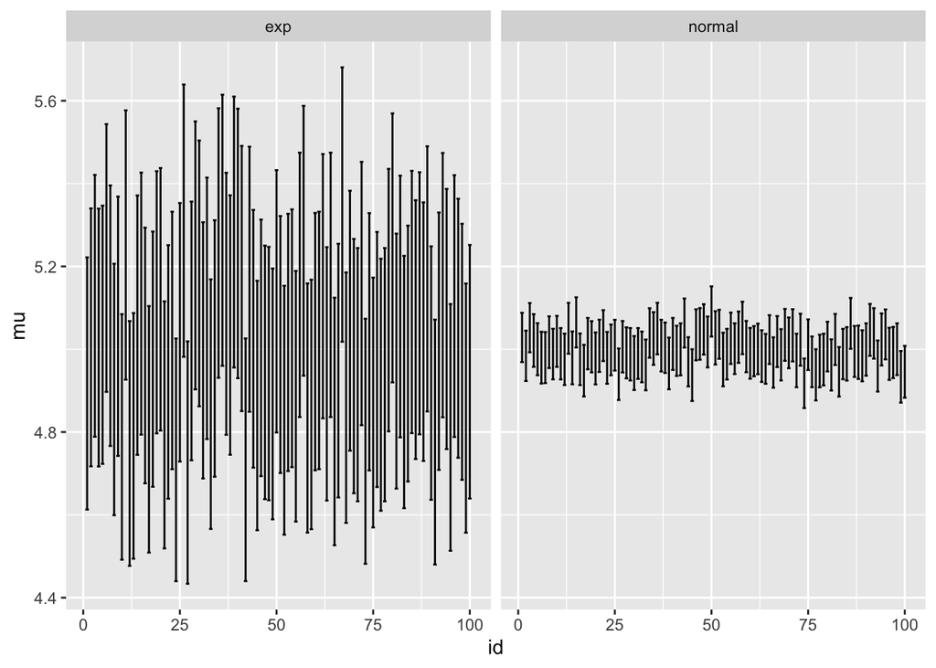

```r
library(ggplot2)
library(purrr)
library(dplyr, warn.conflicts = FALSE)

# Set mean = 5 and sd = 1
mu <- 5
sigma <- 1
n <- 1000

x_norm <- map_df(1:100, ~normal_confint(.x, rnorm(n, mean = mu, sd = sigma)))
x_exp <- map_df(1:100, ~exp_confint(.x, rexp(n, rate = 1/mu)))

bind_rows(x_norm, x_exp) %>%
ggplot() +
  geom_errorbar(aes(x = id, y = mu, ymin = low, ymax = high)) +
  facet_wrap(~type)
```

If we set $\sigma = \sqrt{25}$, then we obtain similar CIs from both distributions.

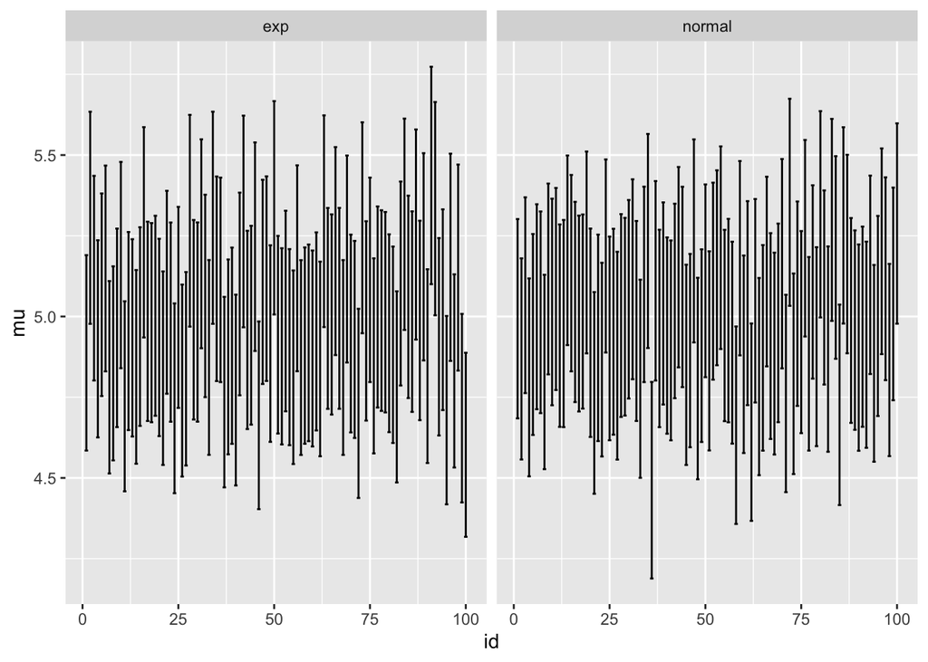

```r
# Set mean = 5 and sd = sqrt(25)
mu <- 5
sigma <- sqrt(25)
n <- 1000

x_norm <- map_df(1:100, ~normal_confint(.x, rnorm(n, mean = mu, sd = sigma)))
x_exp <- map_df(1:100, ~exp_confint(.x, rexp(n, rate = 1/mu)))

bind_rows(x_norm, x_exp) %>%
ggplot() +
  geom_errorbar(aes(x = id, y = mu, ymin = low, ymax = high)) +
  facet_wrap(~type)
```

Let’s do the simulation again but calculate the confidence interval of the mean of the exponential distribution incorrectly using the t distribution formula. The interval estimates are almost identical but small differences can still be observed.

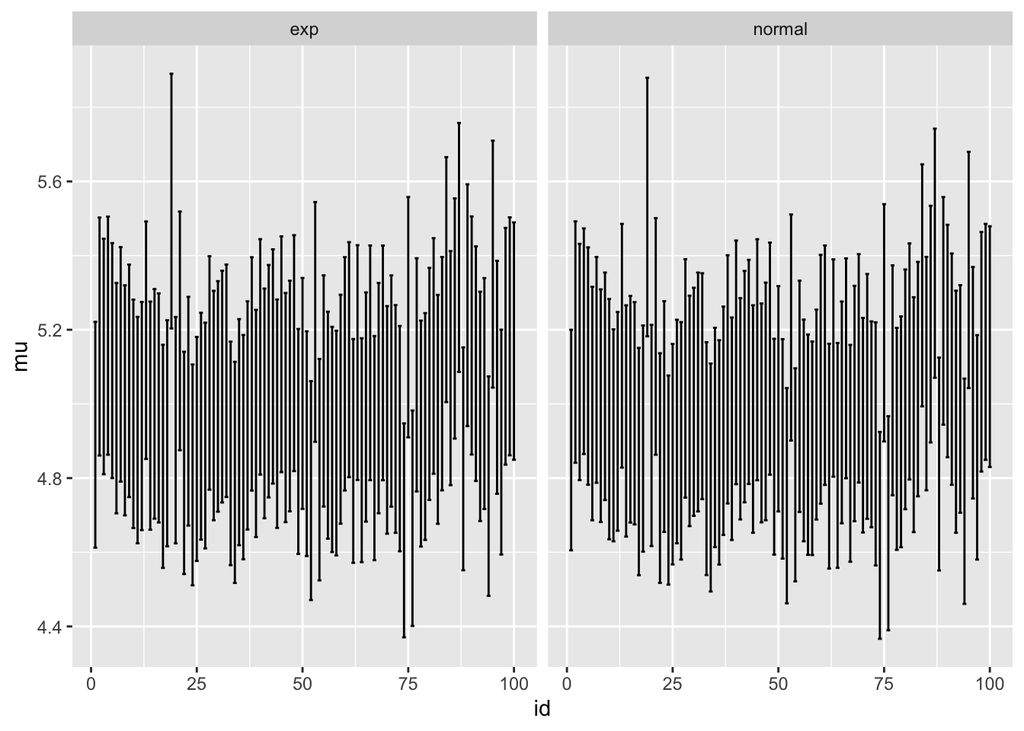

```r
exp_sample <- map(1:100, ~rexp(n, rate = 1/mu))
x_exp <- map_df(1:100, ~exp_confint(.x, exp_sample[[.x]]))
x_exp_wrong <- map_df(1:100, ~normal_confint(.x, exp_sample[[.x]]))

bind_rows(x_exp_wrong, x_exp) %>%
ggplot() +
  geom_errorbar(aes(x = id, y = mu, ymin = low, ymax = high)) +
  facet_wrap(~type)
```

## References

Casella, George, and Roger L Berger. 2002. *Statistical Inference*. Cengage Learning.